# DATA7440, Final Assignment

Aleksei Luchinsky

2023-04-12

# Loading packages

```r
suppressPackageStartupMessages(library(glmnet))
suppressPackageStartupMessages(library(RWeka))
suppressPackageStartupMessages(library(pre))
suppressPackageStartupMessages(library(randomForest))
suppressPackageStartupMessages(library(caret))
suppressPackageStartupMessages(library(dplyr))
suppressPackageStartupMessages(library(magrittr))
suppressPackageStartupMessages(library(ggplot2))
suppressPackageStartupMessages(library(iml))

# I need to attach these libraries to suppress messages from Interaction$new
suppressPackageStartupMessages(library(fs))
suppressPackageStartupMessages(library(xml2))
suppressPackageStartupMessages(library(jsonlite))
suppressPackageStartupMessages(library(broom))
suppressPackageStartupMessages(library(dbplyr))
suppressPackageStartupMessages(library(readr))
suppressPackageStartupMessages(library(httr))
suppressPackageStartupMessages(library(gargle))
suppressPackageStartupMessages(library(rvest))
suppressPackageStartupMessages(library(googlesheets4))
suppressPackageStartupMessages(library(hms))
```

# Problem 1

```r
load("./data/external/apipop1.RData")
str(apipop_train1)
```

```
## 'data.frame':    4474 obs. of  16 variables:
##  $ awards  : Factor w/ 2 levels "No","Yes": 1 2 1 1 1 1 2 2 2 2 ...
##  $ stype   : Factor w/ 3 levels "E","H","M": 1 1 2 2 2 2 1 1 1 1 ...
##  $ meals   : int  88 70 31 4 37 9 17 21 42 65 ...
##  $ ell     : int  13 32 18 3 29 2 3 12 16 48 ...
##  $ mobility: int  13 37 13 7 9 6 14 12 16 20 ...
##  $ pct.resp: int  83 90 75 90 95 89 89 99 58 57 ...
##  $ not.hsg : int  27 21 39 1 41 1 7 10 14 10 ...
##  $ hsg     : int  36 37 20 8 19 13 36 35 16 26 ...
##  $ some.col: int  30 33 19 19 19 29 25 18 34 27 ...
##  $ col.grad: int  4 9 20 44 17 39 27 26 22 25 ...
##  $ grad.sch: int  2 1 2 29 4 17 5 11 14 12 ...
##  $ avg.ed  : num  2.18 2.32 2.25 3.91 2.25 ...
##  $ full    : int  79 79 89 100 91 94 89 100 95 63 ...
##  $ emer    : int  14 21 11 4 9 6 11 0 5 37 ...
##  $ enroll  : int  275 325 990 2306 2132 1215 262 377 639 509 ...
##  $ api.stu : int  216 278 809 2115 1205 1144 226 337 570 435 ...
```

## Part 1

Preparing train data

```r
y.train <- apipop_train1$awards
y.test <- apipop_test1$awards
```

### a) construct a LASSO model that predicts whether or not a school qualified for it’s award program. Use 5-fold cross validation on the apipop_train1 dataset to determine the penalty parameter and specify the seed 7440 prior to running the model.

```r
set.seed(7440)
cv.lasso.model <<- cv.glmnet(
  x = data.matrix(apipop_train1[,-1]),
  y = apipop_train1[,1],
  alpha = 1, standardize = TRUE, nfolds = 5, family = "binomial")
```

The best penalty parameter is

```r
cv.lasso.model$lambda.min
```

```
## [1] 0.0005778871
```

```r
lasso.best.lambda <- cv.lasso.model$lambda.min
```

Here is the modal trained with this value of parameter

```r
lasso.best.model <- glmnet(
  x = data.matrix(apipop_train1[,-1]),
  y = apipop_train1[,1],
  alpha = 1, lambda = lasso.best.lambda, family = "binomial")
```

### b) Now apply a one rule algorithm to determine the feature that most explains the award outcomes.

```r
oneR.model <- OneR::OneR(awards ~ ., data = apipop_train1)
oneR.model
```

```
##
## Call:
## OneR.formula(formula = awards ~ ., data = apipop_train1)
##
## Rules:
## If stype = E then awards = Yes
## If stype = H then awards = No
## If stype = M then awards = Yes
##
## Accuracy:
## 3143 of 4474 instances classified correctly (70.25%)
```

As you can see, the feature, that is most useful to explain the outcome is **stype**

### c) Now apply a sequential covering algorithm to expand the rule set derived in B.

```r
seq.model <- JRip(awards ~ ., data = apipop_test1)
seq.model
```

```
## JRIP rules:
## ===========
##
## (enroll >= 687) and (stype = H) => awards=No (154.0/48.0)
## (grad.sch <= 9) and (enroll >= 1082) => awards=No (42.0/10.0)
## (enroll >= 600) and (not.hsg >= 24) and (stype = M) => awards=No (48.0/19.0)
## (stype = H) => awards=No (35.0/14.0)
##  => awards=Yes (1220.0/314.0)
##
## Number of Rules : 5
```

As you can see, the **stype** variable is part of almost all of the rules, so it is important

### d) Now apply a rule-fit algorithm to determine features and possible interaction effects that are important for explaining award qualification. For this model set the seed to be 2021 and also use 5 folds.

```r
set.seed(2021)
rule.fit.model <- pre(awards ~ .,
                       data = apipop_train1,
                       family = "binomial", nfolds = 5
                       )
```

This model also tells that **stype** is the most important variable:

```r
rule.fit.imps <- pre::importance(rule.fit.model)
```

[figure not shown]

```r
rule.fit.imps$baseimps %>% head(10)
```

```
##       rule                                         description        imp
## 1  rule285        stype %in% c("H") & grad.sch <= 38 & ell > 0 0.12101133
## 2  rule592                       enroll <= 864 & api.stu > 271 0.09217272
## 3  rule685                     stype %in% c("E") & meals <= 96 0.08092126
## 4  rule703            avg.ed > 3.11999988555908 & not.hsg <= 3 0.07429032
## 5  rule788                      enroll <= 1093 & api.stu > 296 0.06962418
## 6  rule452    stype %in% c("E", "M") & meals <= 10 & meals > 0 0.06688456
## 7  rule573                   stype %in% c("H", "M") & hsg > 15 0.06617246
## 8  rule676                  stype %in% c("E", "M") & hsg <= 21 0.06140143
## 9   rule10 stype %in% c("H", "M") & avg.ed <= 3.25999999046326 0.05649550
## 10 rule692                             meals > 10 & full <= 96 0.05478058
##    coefficient        sd
## 1   -0.3891980 0.3109249
## 2    0.1874693 0.4916683
## 3    0.1700675 0.4758184
## 4    0.1898695 0.3912705
## 5    0.1422189 0.4895564
## 6    0.2221314 0.3011035
## 7   -0.1641068 0.4032280
## 8    0.1297739 0.4731417
## 9   -0.1410342 0.4005802
## 10  -0.1128615 0.4853787
```

Most important rules here are

1. rule285: stype = “H”, grad.sch <= 38, ell>0, coeff = -0.389. This rule votes for negative answer and it agrees with oneR rule, default rule of the Sequential Covering model
2. rule592: enroll <= 864 & api.stu > 271, coeff = 0.18 Coefficient is positive, to this rule votes for “Yes”. It agrees, with the 1st rule of the Sequential Covering model: rule592 tends to “Yes” for small enroll, while Seq.Cov wants “No” for large enroll
3. rule685: stype = c(“E”) & meals <= 96, coeff = 0.17 Coefficient is positive, to this rule votes for “Yes”. This agrees with the 1st rule of the oneR model.

## Part 2: Using the respective models create a table that provides overall accuracy, sensitivity and specificity for predicting if a school qualified for its awards program using the apipop_test1 as the test set for each of the models you derived in parts a-d of Part 1.

```r
y.test <- apipop_test1$awards
cm.table <- data.frame()
```

I will use this function to collect statistics about model’s accuracy and kappa on training and test sets

```r
fill.table <- function(model_name, pred_func, y_train=apipop_train1$awards, y_test = y.test,
                       trainX = apipop_train1,
                       testX = apipop_test1) {
  train.predictions <- pred_func(trainX)
  cm.train = confusionMatrix(train.predictions, y_train)
  test.predictions <- pred_func(testX)
  cm.test = confusionMatrix(test.predictions, y_test)
  return(data.frame(
    model = model_name,
    test.accuracy = cm.test$overall[1],
    test.kappa = cm.test$overall[2],
    train.accuracy = cm.train$overall[1],
    train.kappa = cm.train$overall[2]
  ))
}
```

### LASSO model

```r
cm.table <- rbind(cm.table,
  fill.table("LASSO",
           pred_func = function(X) {
             probs = predict(lasso.best.model, newx = data.matrix(X), type = "response")
             as.factor(as.vector(ifelse( probs> 0.5, "Yes", "No")))
}, trainX = apipop_train1[,-1], testX = apipop_test1[,-1])
)
```

### OneR

```r
cm.table <- rbind(cm.table,
  fill.table("OneR",
           pred_func = function(X) {
             as.factor(predict(oneR.model, X))
})
)
```

### Sequential model

```r
cm.table <- rbind(cm.table,
  fill.table("SeqCover",
           pred_func = function(X) {
             as.factor(predict(seq.model, X))
})
)
```

### Rule Fit

```r
cm.table <- rbind(cm.table,
  fill.table("RuleFit",
           pred_func = function(X) {
             probs = predict(rule.fit.model, newdata = X, type = "response")
             as.factor(as.vector(ifelse( probs> 0.5, "Yes", "No")))
})
)
```

```r
rownames(cm.table) <- 1:nrow(cm.table)
cm.table %>% mutate_if(is.numeric, round, digits = 3) %>% arrange(test.accuracy)
```

```
##      model test.accuracy test.kappa train.accuracy train.kappa
## 1    LASSO         0.705      0.217          0.700       0.173
## 2     OneR         0.708      0.226          0.703       0.188
## 3  RuleFit         0.712      0.256          0.719       0.248
## 4 SeqCover         0.730      0.318          0.701       0.225
```

As you can see, sequential covering is the best model both in terms of test accuracy and test kappa.

## Part 3: For every model for which it is appropriate, derive the variable importance measures (feature specific importances, not rule specific importances) and create another table that lists the top 4 most important features for predicting whether a school qualified for it’s award program.

### LASSO

```r
lasso.imps <- lasso.best.model %>% coef %>% as.matrix %>% as.data.frame %>%
  slice(-1) %>% abs %>% arrange(desc(s0))
head(lasso.imps)
```

```
##                   s0
## stype    0.375712635
## grad.sch 0.015816183
## full     0.015248647
## emer     0.013521232
## meals    0.007729355
## ell      0.005204630
```

**stype** is the most important variable

### One R

```r
oneR.model
```

```
##
## Call:
## OneR.formula(formula = awards ~ ., data = apipop_train1)
##
## Rules:
## If stype = E then awards = Yes
## If stype = H then awards = No
## If stype = M then awards = Yes
##
## Accuracy:
## 3143 of 4474 instances classified correctly (70.25%)
```

As you can see, only **stype** variable is important in oneR model

### Sequential Covering

Here is the list of the rules

```r
seq.model
```

```
## JRIP rules:
## ===========
##
## (enroll >= 687) and (stype = H) => awards=No (154.0/48.0)
## (grad.sch <= 9) and (enroll >= 1082) => awards=No (42.0/10.0)
## (enroll >= 600) and (not.hsg >= 24) and (stype = M) => awards=No (48.0/19.0)
## (stype = H) => awards=No (35.0/14.0)
##  => awards=Yes (1220.0/314.0)
##
## Number of Rules : 5
```

The following models enter these rules and are important for making the decisions:

- stype
- enroll
- grad.sch
- not.hsg

### Rule Fit

```r
rule.fit.imps <- pre::importance(rule.fit.model, plot = FALSE)
rule.fit.imps$varimps[1:4, ]
```

```
##   varname       imp
## 1   stype 0.3570190
## 2   meals 0.2064637
## 3  enroll 0.1170933
## 4 api.stu 0.1064105
```

To summarize, all models tell that **stype** is the most important variable. Such variables as **enroll**, **grad.sch**, **meals** are also often present in the list of important predictors

## Part 4: Now compute a random forest model to predict whether or not a school qualifies for its awards program (using the training data: apipop_train1) with 750 trees and default value of the mtry parameter. Prior to running the model, set the seed to be 429. Using your model:

```r
set.seed(429)
rf.model <- randomForest(awards ~ ., data = apipop_train1, ntree = 750)
```

Train accuracy and kappa of this model is perfect. By accuracy on the test subset it is not as good:

```r
 cm.table <- rbind(cm.table,
  fill.table("RF",
           pred_func = function(X) {
             predict(rf.model, newdata = X)
})
)
rownames(cm.table) <- 1:nrow(cm.table)
cm.table <- unique(cm.table)
cm.table %>% mutate_if(is.numeric, round, digits = 3) %>% arrange(test.accuracy)
```

```
##      model test.accuracy test.kappa train.accuracy train.kappa
## 1    LASSO         0.705      0.217          0.700       0.173
## 2       RF         0.706      0.261          1.000       1.000
## 3     OneR         0.708      0.226          0.703       0.188
## 4  RuleFit         0.712      0.256          0.719       0.248
## 5 SeqCover         0.730      0.318          0.701       0.225
```

### a) create an overall interaction plot that displays the overall H statistic for each of the features.

Here is the code to calculte one-feature H-staistics

```r
set.seed(123)
suppressPackageStartupMessages(
  predictor1 <-  Predictor$new(rf.model, dat = apipop_test1, y = apipop_test1$awards)
)
suppressPackageStartupMessages(
  rf.interaction1 <- Interaction$new(predictor1)
)
```

```r
rf.interaction1$results %>% head(8)
```

```
##    .feature .class .interaction
## 1:   awards     No  0.000862614
## 2:   awards    Yes  0.000862614
## 3:    stype     No  0.937339368
## 4:    stype    Yes  0.937339368
## 5:    meals     No  0.015153293
## 6:    meals    Yes  0.015153293
## 7:      ell     No  0.324171233
## 8:      ell    Yes  0.324171233
```

As you can see, the number of h-statistics values is doubled (two values for each feature, corresponding to award = “Yes” and “No”). It turns out, however, that these values are exactly the same

```r
as.data.frame(rf.interaction1$results) %>%
  tidyr::pivot_wider(names_from = .class, values_from = .interaction) %>%
  mutate(ratio = Yes/No) %>%
  head(10)
```

```
## # A tibble: 10 × 4
##    .feature       No      Yes ratio
##    <chr>       <dbl>    <dbl> <dbl>
##  1 awards   0.000863 0.000863  1.00
##  2 stype    0.937    0.937     1
##  3 meals    0.0152   0.0152    1.00
##  4 ell      0.324    0.324     1
##  5 mobility 0.542    0.542     1
##  6 pct.resp 0.435    0.435     1
##  7 not.hsg  0.546    0.546     1
##  8 hsg      0.318    0.318     1
##  9 some.col 0.0473   0.0473    1.00
## 10 col.grad 0.182    0.182     1
```

For this reason I will be interested only in .class = “Yes” part

Here is the plot

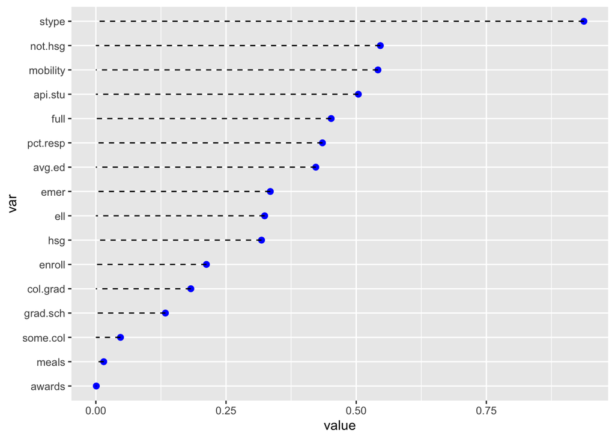

```r
h.res <- data.frame(rf.interaction1$results) %>%
  filter(.class=="Yes") %>%
  transmute(var=.feature, value=.interaction) %>%
  arrange(value) %>%
  mutate(var = factor(var, levels = var))
ggplot(h.res, aes(y=var, yend=var, xend = 0, x=value)) + geom_point(color = "blue", cex = 2) +
  geom_segment(linetype = 2)
```

As you can see, **stype** has the largest H-score. This agrees with our previous results

### b) Using the feature with the highest overall H statistic, create an additional plot that shows the H statistics related to this specific feature

```r
set.seed(456)
interactSTYPE <- Interaction$new(predictor1, feature = "stype")
```

Again, we have to identical sets of the statistics, here is ordered plot of one of them:

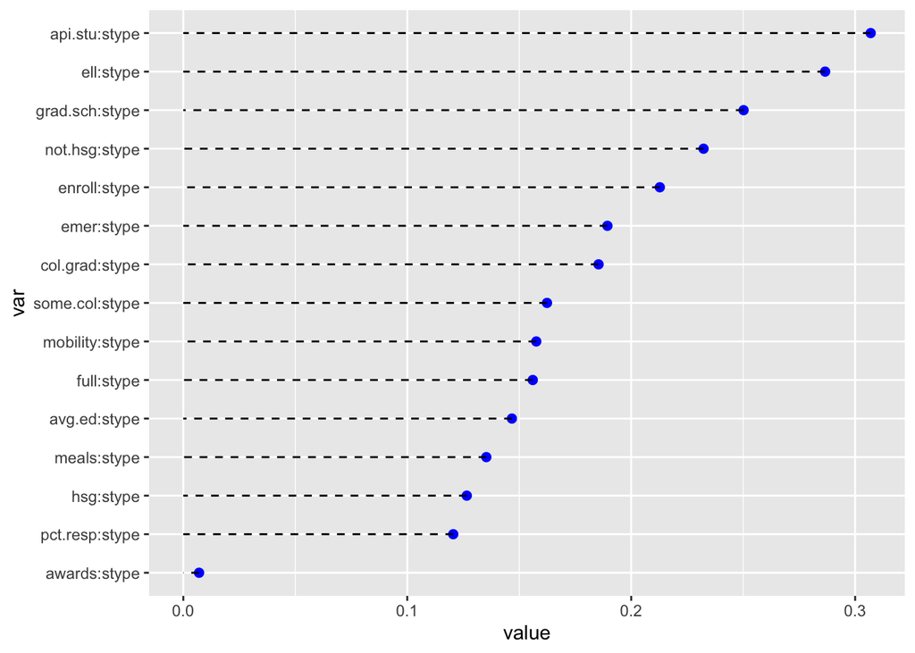

```r
h2.res <- data.frame(interactSTYPE$results) %>%
  filter(.class=="Yes") %>%
  transmute(var=.feature, value=.interaction) %>%
  arrange(value) %>%
  mutate(var = factor(var, levels = var))
ggplot(h2.res, aes(y=var, yend=var, xend = 0, x=value)) + geom_point(color = "blue", cex = 2) +
  geom_segment(linetype = 2)
```

### c) Is the information in the second plot consistent with the some of the rules the Rule Fit model is reporting? Why or why not?

As you can see, the highest h-statistic value here is for api.stu : stype interaction. For Rule Fit model there is only one rule, containing both of these variables, its importance is not very large

```r
rule.fit.imps$baseimps %>% filter(grepl("stype", description) & grepl("api.stu", description))
```

```
##      rule                                     description        imp
## 1 rule617 stype %in% c("E") & meals <= 78 & api.stu > 224 0.03014867
##   coefficient        sd
## 1  0.06076506 0.4961514
```

```r
rule.fit.imps$baseimps %>% filter(grepl("stype", description) & grepl("ell", description))
```

```
##      rule                                  description       imp coefficient
## 1 rule285 stype %in% c("H") & grad.sch <= 38 & ell > 0 0.1210113 -0.38919799
## 2 rule567    stype %in% c("E") & hsg <= 20 & ell <= 24 0.0523657  0.13270131
## 3 rule722            stype %in% c("H", "M") & ell > 12 0.0349404 -0.09901619
##          sd
## 1 0.3109249
## 2 0.3946133
## 3 0.3528757
```

### d) What is the H-statistic value corresponding to the variables included in the top- most important rule in the rule fit model that involves only two predictors? (Be sure to indicate what the top-most important rule with two features is from your rule fit model, along with it’s importance) as well as the plot of that rule from the RuleFit model.

```r
rule.fit.imps$baseimps %>% arrange(desc(imp)) %>% head(10)
```

```
##       rule                                         description        imp
## 1  rule285        stype %in% c("H") & grad.sch <= 38 & ell > 0 0.12101133
## 2  rule592                       enroll <= 864 & api.stu > 271 0.09217272
## 3  rule685                     stype %in% c("E") & meals <= 96 0.08092126
## 4  rule703            avg.ed > 3.11999988555908 & not.hsg <= 3 0.07429032
## 5  rule788                      enroll <= 1093 & api.stu > 296 0.06962418
## 6  rule452    stype %in% c("E", "M") & meals <= 10 & meals > 0 0.06688456
## 7  rule573                   stype %in% c("H", "M") & hsg > 15 0.06617246
## 8  rule676                  stype %in% c("E", "M") & hsg <= 21 0.06140143
## 9   rule10 stype %in% c("H", "M") & avg.ed <= 3.25999999046326 0.05649550
## 10 rule692                             meals > 10 & full <= 96 0.05478058
##    coefficient        sd
## 1   -0.3891980 0.3109249
## 2    0.1874693 0.4916683
## 3    0.1700675 0.4758184
## 4    0.1898695 0.3912705
## 5    0.1422189 0.4895564
## 6    0.2221314 0.3011035
## 7   -0.1641068 0.4032280
## 8    0.1297739 0.4731417
## 9   -0.1410342 0.4005802
## 10  -0.1128615 0.4853787
```

The most important rule, that includes two features is rule592: enroll <= 864 & api.stu > 271

```r
set.seed(456)
interactEnroll <- Interaction$new(predictor1, feature = "enroll")
```

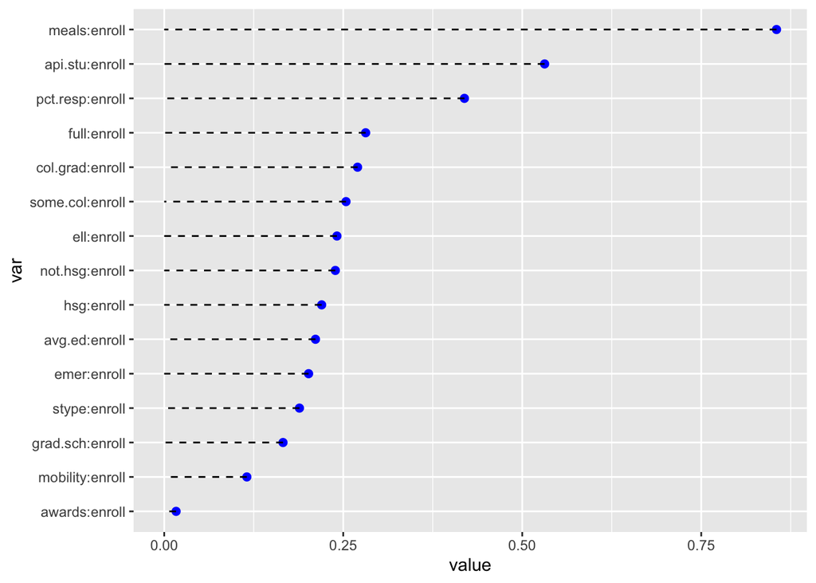

```r
h2.res <- data.frame(interactEnroll$results) %>%
  filter(.class=="Yes") %>%
  transmute(var=.feature, value=.interaction) %>%
  arrange(value) %>%
  mutate(var = factor(var, levels = var))
ggplot(h2.res, aes(y=var, yend=var, xend = 0, x=value)) + geom_point(color = "blue", cex = 2) +
  geom_segment(linetype = 2)
```

As you can see, this interaction is quite important, its H-value is 0.53

```r
interactEnroll$results %>% filter(grepl("api.stu", .feature))
```

```
##          .feature .class .interaction
## 1: api.stu:enroll     No    0.5312866
## 2: api.stu:enroll    Yes    0.5312866
```

It is not the maximal H-value for interactions, though